# Data Science II

## Mapping Mexico

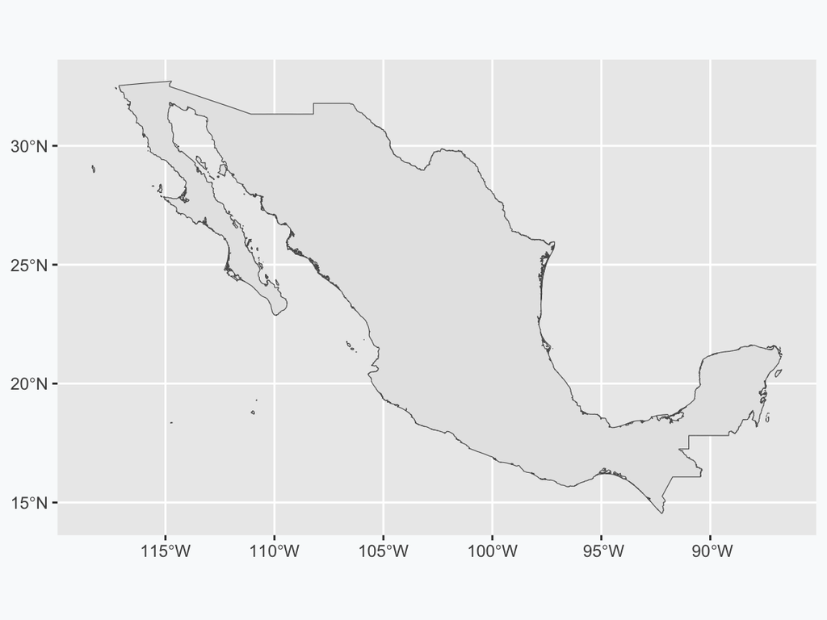

```r
#Step1: Load ggplot2
library(ggplot2)

#Step2: Read the country outline
mex_country <- st_read(
  "../data/gadm41_MEX_shp/gadm41_MEX_0.shp",
  quiet = TRUE)

#Step3: Map it -- the data is already WGS84, so no coord_sf needed
ggplot() +
  geom_sf(data = mex_country)
```

## Adding the States

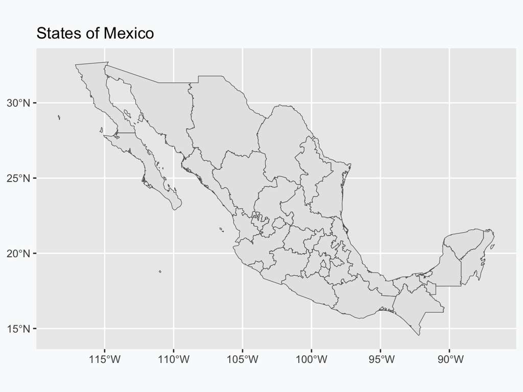

```r
ggplot() +
  geom_sf(data = mex_simple) +
  labs(title = "States of Mexico")
```

## Zooming In

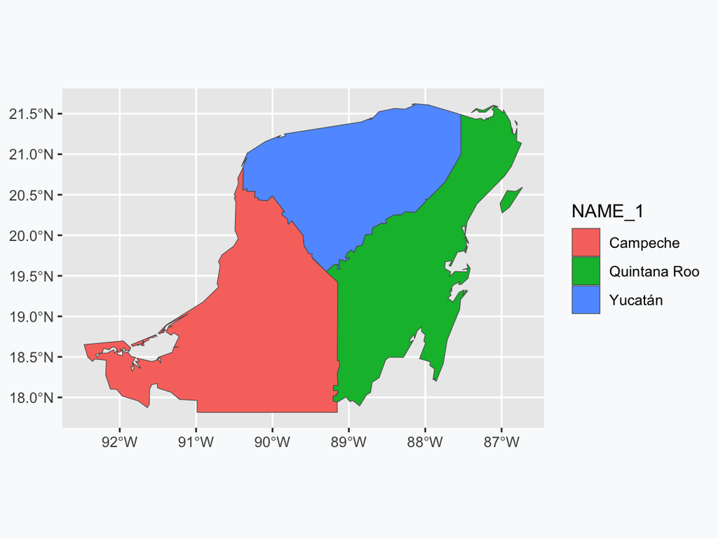

```r
#Step1: Keep only the three peninsula states
peninsula <- mex_simple[
  mex_simple$NAME_1 %in%
    c("Yucatán", "Campeche",
      "Quintana Roo"), ]

#Step2: Map them, coloured by state
ggplot() +
  geom_sf(data = peninsula,
          aes(fill = NAME_1))
```

## Putting It in Your Document

Everything from this session, as one chunk in your own document:

````markdown
```{r}
#| label: fig-mexico
#| fig-cap: "States of Mexico"
#| fig-width: 8
#| fig-height: 5
#| cache: true
library(sf)
library(ggplot2)

mex <- st_read("../data/gadm41_MEX_shp/gadm41_MEX_1.shp", quiet = TRUE)
mex <- st_simplify(mex, dTolerance = 0.02)   # degrees: the CRS it arrived in

ggplot() + geom_sf(data = mex)
```
````

The data stays in WGS84 and so does the map. There is only one CRS to keep track of.

## Where AI Gets This Wrong

Four things it cannot see, all of which you met today:

- it learned on **`sp`**, retired in 2023, so expect `readOGR()`
- it cannot see your **CRS**, so it guesses the units: `dTolerance = 2000`, or `0.02`?
- it does not know your file’s **vintage** — GADM still says *Distrito Federal*
- longitude and latitude reversed runs perfectly well, and puts Mexico in the Indian Ocean

None of these throws an error. Every one produces a map.

**Note**

Use it. Then check `st_crs()`, plot the result, and confirm the units. The disclosure rules are in the syllabus.

## What Have We Learned?

- The Earth is an **oblate spheroid**, located by **latitude and longitude**
- A **CRS** combines an ellipsoid, a geoid, and a **datum**
- **Geographic** systems use degrees, **projected** systems use metres — every projection distorts something
- CRS mistakes announce themselves when you **combine layers**; `st_transform` is the fix
- Keep data in **WGS84**; project only when you measure
- An `sf` object is a dataframe with a **geometry column**, and `geom_sf()` draws whatever is in it
- A shapefile is **at least four files**, and the geometry type decides what your map looks like